# Posterior

现在问题至少不卡着了。然后就是这个loss function的问题。I am thinking maybe I should change those components in the loss function into the components before taking exponential, since the denominator is $\sigma^2$… let’s try! Define this loss function as **Dif3** :

```r
Dif3 <- function(x11, ssm, data, sigma){

  x11_trend <- series(x11, 'd12')
  x11_seasonal <- series(x11, 'd10')
  x11_irregular <- series(x11, 'd13')

  ssm_trend <- coef(ssm, states = 'trend')
  ssm_seasonal <- -rowSums(coef(ssm, states='seasonal'))
  ssm_irregular <- log(data)[-1] - ssm_trend[-1] - ssm_seasonal[-length(data)]

  D <-  sum((log(x11_irregular[-1])-ssm_irregular)^2)/sigma[1] +
    sum((log(x11_trend)-ssm_trend)^2)/sigma[2] +
    sum((log(x11_seasonal[-1])-ssm_seasonal[-length(data)])^2)/sigma[3]

  return(D)
}

exhaustion3 <- function(data){

  Difference <- c()
  index <- c()

  x11 <- seas(data, x11='')
   for (i in 1:50) {
     for (j in 1:50) {

           ssmm <- SSModel(log(data) ~ SSMtrend(1, Q=list(j)) +
                     SSMseasonal(12, sea.type = 'dummy', Q = 1),
                   H = i)
           ssm <- KFS(ssmm)

           sigma <- c(i, j, 1)

           dif <- Dif3(x11, ssm, data, sigma)

           Difference <- c(Difference, dif)

           index <- rbind(index, sigma)
      }
   }

  df <- data.frame(variance=index, difference = Difference)
  return(df)
}
```

```r
data8_exhaustion3 <- exhaustion3(data8)
data8_exhaustion3[which.min(data8_exhaustion3$difference),]
```

```
##           variance.1 variance.2 variance.3  difference
## sigma.303          7          4          1 0.003701732
```

```r
data8_exhaustion3[which.max(data8_exhaustion3$difference),]
```

```
##            variance.1 variance.2 variance.3 difference
## sigma.2450         50          1          1 0.02110187
```

Very good! Let’s see the result from 741 on data8:

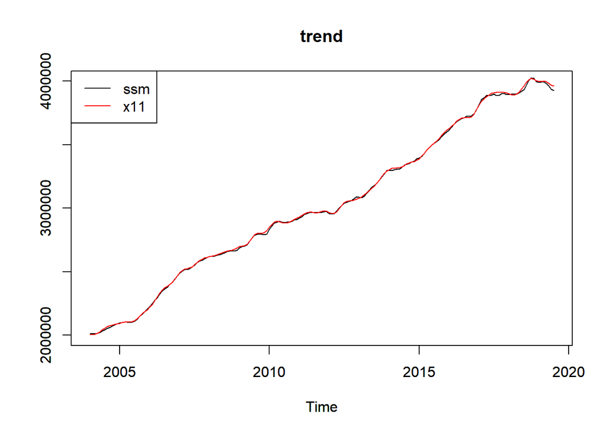

```r
data8_ssmm <- SSModel(log(data8) ~ SSMtrend(1, Q=list(4)) +
                     SSMseasonal(12, sea.type = 'dummy', Q = 1),
                   H = 7)
data8_ssm <- KFS(data8_ssmm)

data8_ssm_trend <- exp(coef(data8_ssm, states = 'trend'))
data8_ssm_seasonal <- exp(-rowSums(coef(data8_ssm, states='seasonal')))
data8_ssm_irregular <- data8[-1]/(data8_ssm_trend[-1]*data8_ssm_seasonal[-length(data8)])

plot(data8_ssm_trend,type='l',ylim=c(2*10^6,4*10^6),ylab='')
par(new=TRUE)
plot(series(data8_x11,'d12'),ylim=c(2*10^6,4*10^6),ylab='',col=2)
title(main='trend')
legend('topleft', c('ssm','x11'),col=c(1,2),lty=1)
```

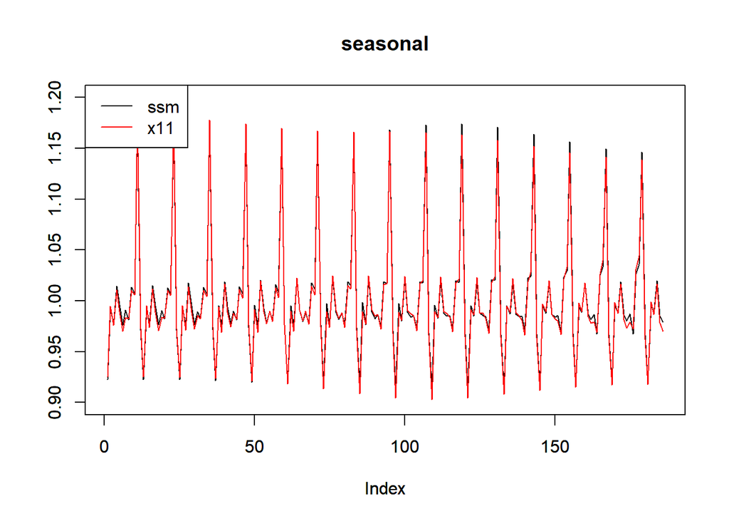

```r
plot(data8_ssm_seasonal[-length(data8)],type='l',ylab='',ylim=c(0.9,1.2))
par(new=TRUE)
plot(series(data8_x11,'d10')[-1],type='l',ylab='',ylim=c(0.9,1.2),col=2)
title('seasonal')
legend('topleft', c('ssm','x11'),col=c(1,2),lty=1)
```

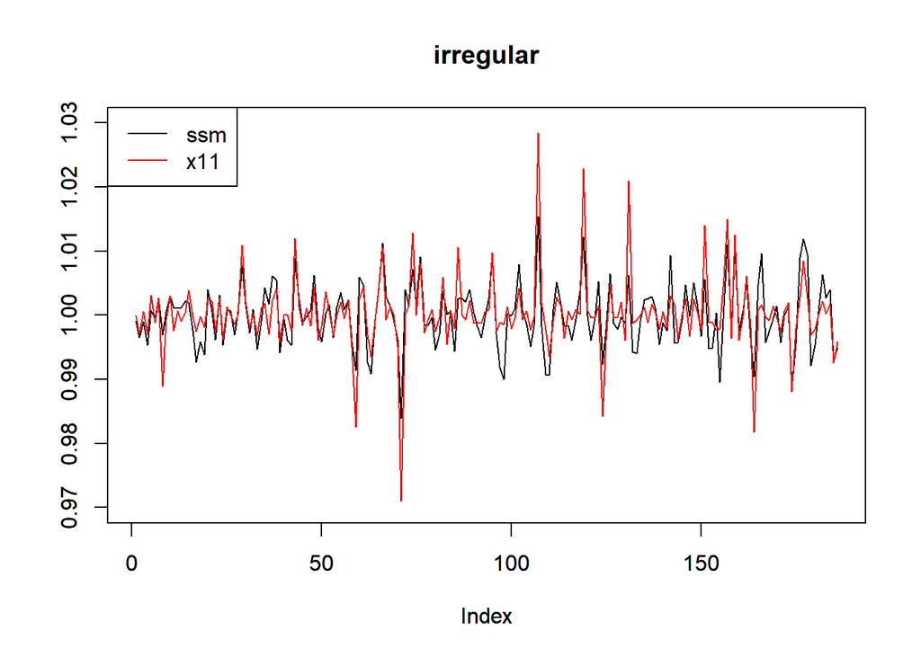

```r
plot(data8_ssm_irregular,type='l',ylim=c(0.97,1.03),ylab='')
par(new=TRUE)
plot(series(data8_x11,'d13')[-1],type='l',ylim=c(0.97,1.03),ylab='',col=2,)
title('irregular')
legend('topleft', c('ssm','x11'),col=c(1,2),lty=1)
```

It seems good. Let’s try exhaustion on some other datasets:

```r
data1_exhaustion3 <- exhaustion3(data1)
data1_exhaustion3[which.min(data1_exhaustion3$difference),]
```

```
##           variance.1 variance.2 variance.3 difference
## sigma.204          5          5          1 0.01063238
```

```r
data2_exhaustion3 <- exhaustion3(data2)
data2_exhaustion3[which.min(data2_exhaustion3$difference),]
```

```
##           variance.1 variance.2 variance.3 difference
## sigma.405          9          6          1 0.04709275
```

```r
data3_exhaustion3 <- exhaustion3(data3)
data3_exhaustion3[which.min(data3_exhaustion3$difference),]
```

```
##           variance.1 variance.2 variance.3 difference
## sigma.456         10          7          1 0.07709725
```

Since we have solved the exhaustion problem then we need to look at the likelihood!

既然在loss里components要取log形式的，那么在likelihood里应该也取log的喽！Let’s define a new (log)likelihood function:

```r
loglikelihood <- function(data, trend, season, sigma){

  n <- length(data)
  a <- 0
  for (i in 12:n)  a <- a + (sum(season[(i-11):i]))^2
  l <- -(n-11)/2 * log(sigma[1]) -
    (n-11)/2 * log(sigma[2]) - (n-11)/2 * log(sigma[3]) -
    sum((data[-c(1:11)]-trend[-c(1:11)]-season[-c(1:10,n)])^2)/(2*sigma[1]) -
    sum((trend[-c(1:11)]-trend[-c(1:10,n)])^2)/(2*sigma[2]) -
    a / (2*sigma[3])
  return(l)

}

# define the log likelihood matrix
loglikelihood_matrix <- function(data){
  LL <- c()
  index <- c()
   for (i in 1:100) {
     for (j in 1:100) {

         ssmm <- SSModel(data ~ SSMtrend(1, Q=list(j)) +
                   SSMseasonal(12, sea.type = 'dummy', Q = 1),
                 H = i)
         ssm <- KFS(ssmm)

         ssm_trend <- coef(ssm, states = 'trend')
         ssm_seasonal <- -rowSums(coef(ssm, states='seasonal'))
  #      ssm_seasadj <- data[-1] - ssm_seasonal[-length(data)] # length is shorter
         sigma <- c(i*0.05, j*0.05, 1)

         ll <- loglikelihood(data, ssm_trend, ssm_seasonal, sigma)
         LL <- c(LL, ll)
         index <- rbind(index, sigma)
      }
   }
  df <- data.frame(variance=index, loglikelihood=LL)
  return(df)
}
```

After copying these definitions, I found that there is no need to define new function…cause in loglikelihood_matrix function, we will input the log(data) directly. Let’s see the result:

```r
data1_llmatrix <- loglikelihood_matrix(log(data1))
data2_llmatrix <- loglikelihood_matrix(log(data2))
data3_llmatrix <- loglikelihood_matrix(log(data3))
data8_llmatrix <- loglikelihood_matrix(log(data8))
```

```r
data1_llmatrix[which.max(data1_llmatrix$loglikelihood),]
```

```
##       variance.1 variance.2 variance.3 loglikelihood
## sigma       0.05       0.05          1      527.1745
```

```r
data2_llmatrix[which.max(data2_llmatrix$loglikelihood),]
```

```
##       variance.1 variance.2 variance.3 loglikelihood
## sigma       0.05       0.05          1      526.8002
```

```r
data3_llmatrix[which.max(data3_llmatrix$loglikelihood),]
```

```
##       variance.1 variance.2 variance.3 loglikelihood
## sigma       0.05       0.05          1      526.5821
```

```r
data8_llmatrix[which.max(data8_llmatrix$loglikelihood),]
```

```
##       variance.1 variance.2 variance.3 loglikelihood
## sigma       0.05       0.05          1      527.1697
```

行吧，我傻了。虽然我解决了如何找到best fit的问题，但是mle这里我们还是会prefer the smallest value because of the loglikelihood expression.

**一番演草**

For the transformation-needed cases, the critical point is very small and for normal cases, critical points are very large generally.

Let’s check whether I am right or not: suppose the variance belongs to c(0.0001，0.005). If my inference is correct, then the mle should not be the minimum value.

```r
# define the log likelihood matrix
loglikelihood_matrix <- function(data){
  LL <- c()
  index <- c()
   for (i in 1:50) {
     for (j in 1:50) {

         ssmm <- SSModel(data ~ SSMtrend(1, Q=list(j*0.0001)) +
                   SSMseasonal(12, sea.type = 'dummy', Q = 1),
                 H = i*0.0001)
         ssm <- KFS(ssmm)

         ssm_trend <- coef(ssm, states = 'trend')
         ssm_seasonal <- -rowSums(coef(ssm, states='seasonal'))
  #      ssm_seasadj <- data[-1] - ssm_seasonal[-length(data)] # length is shorter
         sigma <- c(i*0.0001, j*0.0001, 1)

         ll <- loglikelihood(data, ssm_trend, ssm_seasonal, sigma)
         LL <- c(LL, ll)
         index <- rbind(index, sigma)
      }
   }
  df <- data.frame(variance=index, loglikelihood=LL)
  return(df)
}

data8_llmatrix <- loglikelihood_matrix(log(data8))
data8_llmatrix[which.max(data8_llmatrix$loglikelihood),]
```

```
##           variance.1 variance.2 variance.3 loglikelihood
## sigma.410      9e-04     0.0011          1      1128.812
```

And just like what we have done for the normal cases, we need to modify/twist the mle to a map estimate that we hope to have.

**SUMMARY 20191115**

I spend quite a long time on these part I think, but different from the name of this file, I haven’t done a lot of things related to bayesian analysis. The main usage of this part is to solve most of little problems that we may meet with different dataset. In a word, this part is to serve our final goal.